# R Notebook

### Data Analysis for the Iris Dataset

```r
library('tidyverse')
```

Loading the dataset

```r
data('iris')
print(iris)
```

| Sepal.Length | Sepal.Width | Petal.Length | Petal.Width | Species |
| --- | --- | --- | --- | --- |
| 5.1 | 3.5 | 1.4 | 0.2 | setosa |
| 4.9 | 3.0 | 1.4 | 0.2 | setosa |
| 4.7 | 3.2 | 1.3 | 0.2 | setosa |
| 4.6 | 3.1 | 1.5 | 0.2 | setosa |
| 5.0 | 3.6 | 1.4 | 0.2 | setosa |
| 5.4 | 3.9 | 1.7 | 0.4 | setosa |
| 4.6 | 3.4 | 1.4 | 0.3 | setosa |
| 5.0 | 3.4 | 1.5 | 0.2 | setosa |
| 4.4 | 2.9 | 1.4 | 0.2 | setosa |
| 4.9 | 3.1 | 1.5 | 0.1 | setosa |

[output cut: 140 more lines]

Understanding the features our dataset has

```r
names(iris)
```

```
[1] "Sepal.Length" "Sepal.Width"  "Petal.Length" "Petal.Width"  "Species"
```

Getting a glimpse of our data to get to understand the structure of our dataset

```r
glimpse(iris)
```

```
Rows: 150
Columns: 5
$ Sepal.Length <dbl> 5.1, 4.9, 4.7, 4.6, 5.0, 5.4, 4.6, 5.0, 4.4, 4.9, 5.4, 4.8, 4.8, 4.3, 5.8, 5.7, 5.4, 5.1, 5.7,…
$ Sepal.Width  <dbl> 3.5, 3.0, 3.2, 3.1, 3.6, 3.9, 3.4, 3.4, 2.9, 3.1, 3.7, 3.4, 3.0, 3.0, 4.0, 4.4, 3.9, 3.5, 3.8,…
$ Petal.Length <dbl> 1.4, 1.4, 1.3, 1.5, 1.4, 1.7, 1.4, 1.5, 1.4, 1.5, 1.5, 1.6, 1.4, 1.1, 1.2, 1.5, 1.3, 1.4, 1.7,…
$ Petal.Width  <dbl> 0.2, 0.2, 0.2, 0.2, 0.2, 0.4, 0.3, 0.2, 0.2, 0.1, 0.2, 0.2, 0.1, 0.1, 0.2, 0.4, 0.4, 0.3, 0.3,…
$ Species      <fct> setosa, setosa, setosa, setosa, setosa, setosa, setosa, setosa, setosa, setosa, setosa, setosa…
```

A brief summary for the dataset

```r
summary(iris)
```

```
  Sepal.Length    Sepal.Width     Petal.Length    Petal.Width          Species
 Min.   :4.300   Min.   :2.000   Min.   :1.000   Min.   :0.100   setosa    :50
 1st Qu.:5.100   1st Qu.:2.800   1st Qu.:1.600   1st Qu.:0.300   versicolor:50
 Median :5.800   Median :3.000   Median :4.350   Median :1.300   virginica :50
 Mean   :5.843   Mean   :3.057   Mean   :3.758   Mean   :1.199
 3rd Qu.:6.400   3rd Qu.:3.300   3rd Qu.:5.100   3rd Qu.:1.800
 Max.   :7.900   Max.   :4.400   Max.   :6.900   Max.   :2.500
```

From the data the species are evently selected.

Displaying the null values

```r
iris %>%
  filter(!complete.cases(.)) %>%
  print()
```

| Sepal.Length | Sepal.Width | Petal.Length | Petal.Width | Species |
| --- | --- | --- | --- | --- |

There are no missing values in our dataset hence we can use the data for modelling

### Data Analysis

Displaying relationships between the variables

```r
iris %>%
  select(-Species) %>%
  cor()
```

```
             Sepal.Length Sepal.Width Petal.Length Petal.Width
Sepal.Length    1.0000000  -0.1175698    0.8717538   0.8179411
Sepal.Width    -0.1175698   1.0000000   -0.4284401  -0.3661259
Petal.Length    0.8717538  -0.4284401    1.0000000   0.9628654
Petal.Width     0.8179411  -0.3661259    0.9628654   1.0000000
```

There is a strong positive relationship between petal length and petal width also a positive strong relationship between Petal Length, Petal Width with Sepal Length. Also there is a relative weak negative relationship between Sepal Width and Petal Length.

### Data Visualization for the strongest relationship

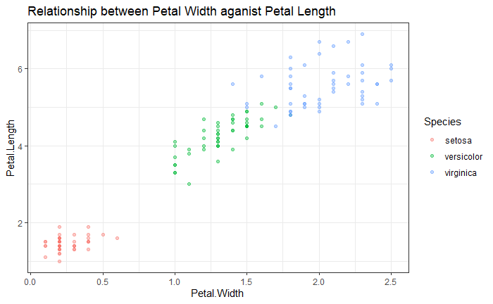

```r
ggplot(iris,aes(x=Petal.Width,y= Petal.Length,color = Species))+
  geom_point(alpha = 0.4)+
  theme_bw()+
  labs(title= "Relationship between Petal Width aganist Petal Length")
```

```r
NA
```

```r
ggplot(iris,aes(Sepal.Length))+
  geom_violin(trim = FALSE)+
  geom_boxplot(width = 0.5)+
  labs(title = "Violin Chart for the Sepal Length variable")+
  theme_bw()
```

[output not shown]

```r
ggplot(iris, aes(y = Sepal.Length)) +
  geom_violin(trim = FALSE, fill = "lightblue", color = "darkblue", alpha = 0.5) +  # Added trim, fill, color, and alpha
  geom_boxplot(width = 0.2, fill = "gray", color = "black", alpha = 0.5) +       # Adjusted width, fill, color, and alpha
  labs(title = "Violin and Box Plot of Sepal Length",
       y = "Sepal Length (cm)") +                                    # Improved title and y-axis label
  theme_bw() +
  theme(plot.title = element_text(hjust = 0.5))  # Centered title
```

[output not shown]

Density plot for the Sepal Width

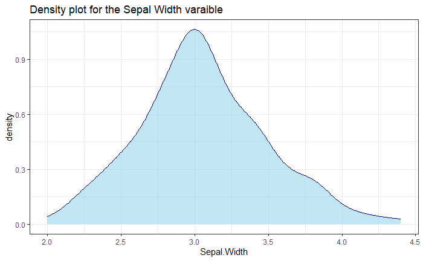

```r
ggplot(iris,aes(x = Sepal.Width))+
         geom_density(fill = "skyblue",color = "darkblue",alpha = 0.5)+
         theme_bw()+
         labs(title = "Density plot for the Sepal Width varaible")
```

```r
NA
```

What about the histogram

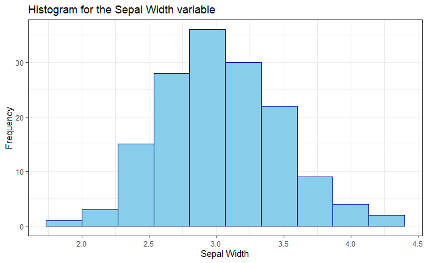

```r
ggplot(iris,aes(x = Sepal.Width))+
  geom_histogram(fill = "skyblue",bins = 10,color = "darkblue")+
  theme_bw()+
  labs(title = "Histogram for the Sepal Width variable",x = "Sepal Width", y = "Frequency")
```

From this it shows that the sepal Width Column is normally distributed with bins = 10

### Boxplots

[figure not shown]

```r
ggplot(iris,aes(x = Sepal.Length))+
  geom_boxplot(width = 0.8 , fill = "maroon",color= "red")+
  geom_point(y = iris$Sepal.Length)+
  theme_bw()+
  labs(title = "Boxplot for the Sepal Length variable",x = "Sepal Length" )
```

From the boxplot we can see that the median is around 5.8 we could try to prove this using the percentiles command

```r
q1 = quantile(iris$Sepal.Length,.25)
q2 = quantile(iris$Sepal.Length,.75)
q3 = q2-q1
q3
```

```
75%
1.3
```

What about using the 50th percentile

```r
q3 = quantile(iris$Sepal.Length,.5)
q3
```

```
50%
5.8
```

Plotting a bar graph for Petal Length aganist species

```r
petal_length_summ <- iris %>%
  select(Petal.Length,Species) %>%
  group_by(Species) %>%
  summarise(mean_petal_length = mean(Petal.Length)) %>%
  print()
```

| Species | mean_petal_length |
| --- | --- |
| setosa | 1.462 |
| versicolor | 4.260 |
| virginica | 5.552 |

Now plotting this data in a graph

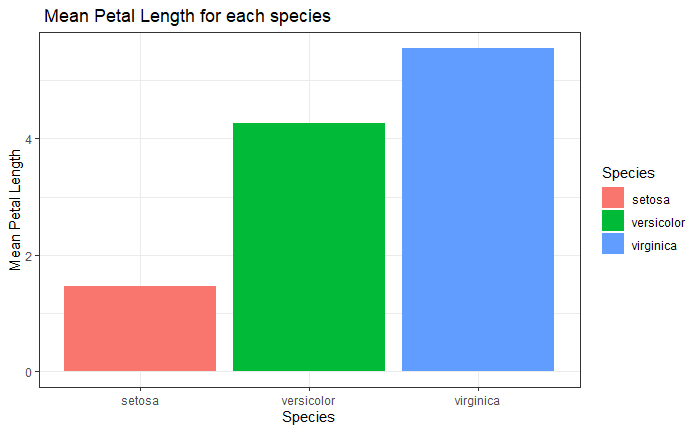

```r
ggplot(petal_length_summ,aes(x = Species , y = mean_petal_length , fill = Species))+
  geom_bar(stat = "identity")+
  theme_bw()+
  labs(title = " Mean Petal Length for each species" , x = "Species" , y = "Mean Petal Length")
```